# Data for: Partitioning inorganic carbon fluxes using paired $O_2$-$CO_2$ sensors in a headwater stream, Costa Rica

Nicholas S. Marzolf

Last updated: June 18, 2021

## Load packages and explore the data

```r
library(dplyr)
library(tidyr)
library(lubridate)
library(ggplot2)
library(cowplot)
library(ggrepel)
library(pander)
library(tidyquant)
library(scales)
library(lmodel2)
library(ellipse)
library(ggsci)
library(purrr)

# Read in hourly data file
Tac_all = readRDS("Tac_all.rds")
```

This file contains hourly data from April 1 - September 27, including: stream and well Vaisala pCO2 sensors (CO2_ppm, wellCO2), YSI sonde (temp.water, pH, DO.obs, DO.sat, cond), discharge (sumQ_m3_hr, meanQ_m3_s), and meterological data (relative humidity (RH), Rainfall, barometric pressure (bp_mmHg)) from the weather station located at La Selva Biological Station. Rainfall is collected at 15-minute intervals, and there data here are aggregated to hourly sums. Discharge is collected at 15-minute intervals, and is shown as both mean discharge for the hour (m3/s) and sum of the 4 contributing measurements (m3/hr). Groundwater discharge (GW_Q) is described in the text. Mean depth is taken from the weir.

```r
glimpse(Tac_all)
```

```
## Rows: 4,324
## Columns: 16
## $ Timestamp  <dttm> 2013-04-01 00:00:00, 2013-04-01 01:00:00, 2013-04-01 02:00~
## $ sumQ_m3_hr <dbl> 0.244, 0.535, 0.617, 0.710, 0.773, 0.834, 0.840, 0.812, 0.7~
## $ meanQ_m3_s <dbl> 0.002033333, 0.002229167, 0.002570833, 0.002958333, 0.00322~
## $ mean_depth <dbl> 0.24300, 0.24575, 0.25025, 0.25500, 0.25800, 0.26075, 0.261~
## $ GW_Q       <dbl> 0.02196, 0.04815, 0.05553, 0.06390, 0.06957, 0.07506, 0.075~
## $ RH         <dbl> 92.850, 93.100, 92.900, 92.600, 93.300, 93.400, 93.350, 93.~
## $ Rainfall   <dbl> 0.254, 0.000, 1.778, 0.000, 1.524, 0.508, 1.016, 1.524, 0.0~
## $ bp_mmHg    <dbl> 755.6687, 755.8967, 756.2283, 756.0831, 755.5855, 755.3016,~
## $ CO2_ppm    <dbl> 6287.696, 6042.019, 6058.962, 6086.072, 6087.767, 6055.574,~
## $ temp.water <dbl> NA, NA, NA, NA, NA, NA, NA, NA, NA, NA, NA, NA, NA, NA, NA,~
## $ pH         <dbl> NA, NA, NA, NA, NA, NA, NA, NA, NA, NA, NA, NA, NA, NA, NA,~
## $ DO.obs     <dbl> NA, NA, NA, NA, NA, NA, NA, NA, NA, NA, NA, NA, NA, NA, NA,~
## $ DO.sat     <dbl> NA, NA, NA, NA, NA, NA, NA, NA, NA, NA, NA, NA, NA, NA, NA,~
## $ cond       <dbl> NA, NA, NA, NA, NA, NA, NA, NA, NA, NA, NA, NA, NA, NA, NA,~
## $ wellCO2    <dbl> 41074.82, 42818.21, 44179.08, 45055.86, 45396.08, 46122.21,~
## $ PAR        <dbl> 0.0000, 0.0000, 0.0000, 0.0000, 0.0000, 0.0000, 0.0000, 0.0~
```

We will use this dataset build on with the following calculations at the hourly resolution and aggregate to daily scale at the end of the document.

## Inorganic carbon chemistry

Here, we calculate the necessary parameters for DIC partitioning and flux calculations.

From pH measured from the sonde, we calculate $[H^+]$ and use the carbonate equilibrium constants, $K_1$ and $K_2$ to calculate $[DIC]$ partitioning coefficients to estimate $[H_2CO_3^*]$, $[HCO_3^-]$, and $[CO_3^{2-}]$ (which we ultimately don’t consider due to the pH). The partioning coefficients, $\alpha_0$, $\alpha_1$, and $\alpha_2$ correspond to the fraction of $[H_2CO_3^*]$, $[HCO_3^-]$, and $[CO_3^{2-}]$, respectively.

$$\alpha_0 = {(1 + \frac{K_1}{[H^+]} + \frac{K_1K_2}{[H^+]^2})^{-1}}$$
$$\alpha_1 = {(1 + \frac{[H^+]}{K_1} + \frac{K_2}{[H^+]})^{-1}}$$
$$\alpha_2 = {(1 + \frac{[H^+]}{K_2} + \frac{[H^+]^2}{K_1K_2})^{-1}}$$

Since we calculate $CO_2$ (as $[H_2CO_3^*]$) using Henry’s Law, we can use the partitioning coefficients to estimate $[DIC]$:
$$[DIC] = \frac{[H_2 CO3^*]}{\alpha_0}$$

From $[DIC]$, we calculate $[HCO3^-]$ as
$$[HCO3^-] = [DIC]*\alpha_1$$

```r
# define carbonate equilibrium constants (reference)
k1 = 10^-6.3  # k1 = [H+][HCO3-]/[H2CO3]
k2 = 10^-10.3 # k2 = [H+][CO32-]/[HCO3-]

Tac_all = Tac_all %>%
  mutate(

    # calculate [H+] from pH
    H = 10^(-1*pH),

    # DIC dissociation constants
    alpha0 = (1 + (k1/H) + ((k1*k2)/(H^2)))^-1,
    alpha1 = (1 + (H/k1) + (k2/H))^-1,
    alpha2 = (1 + (H/k2) + ((H^2)/(k1*k2)))^-1,

    # temperature-corrected Henry's Law constant (atm*L/mol, Plummer and Busenberg 1982)
    kH = 29.41*exp(-2400*(1/(273 + temp.water) - (1/298))),

    # CO2 saturation (mol m-3), assuming 400 ppm
    CO2_sat = ((400/1e6)/kH)*1000,

    # CO2 in the stream and well (mol m-3)
    CO2_aq = ((CO2_ppm/1e6)/kH)*1000,
    CO2_well = ((wellCO2/1e6)/kH)*1000,

    # DIC partitioning; since pH was < 7, CO3 was <0.2% of DIC, and not calculated
    H2CO3 = (1/kH)*(CO2_ppm/1000),    # H2CO3* (mol m-3)
    TotDIC = H2CO3/alpha0,            # total DIC (mol m-3)
    HCO3 = TotDIC * alpha1            # HCO3 (mol m-3)
  )
```

## $CO_2$ flux calculations

### $CO_2$ evasion ($F_{CO2}$)

```r
## seasonal gas exchange coefficients from Oviedo-Vargas et al. (2015)
K_prop_wet = 10.2   # gas exchange coefficient for wet season propane (d-1)
K_prop_dry = 27.2   # gas exchange coefficient for dry season propane (d-1)

# calculate Schmidt numbers for propane, CO2, and O2, using mean temperature (Raymond et al. 2012)
temp_mean = mean(Tac_all$temp.water, na.rm = TRUE)

Sc_prop = 3545.60 - (203.41*temp_mean) + (4.78*(temp_mean^2)) - (0.0404*(temp_mean^3))
Sc_CO2 = 1686.08 - (89.66*temp_mean) + (2.07*(temp_mean^2)) - (0.018*(temp_mean^3))
Sc_O2 = 1568 - (86.04*temp_mean) + (2.142*(temp_mean^2)) - (0.0216*(temp_mean^3))

# Convert to units for CO2 (to calculate CO2 evasion)
K_CO2_dry = K_prop_dry*(Sc_prop/Sc_CO2)^0.7 # gas exchange coefficient for CO2, d-1
K_CO2_wet = K_prop_wet*(Sc_prop/Sc_CO2)^0.7 # gas exchange coefficient for CO2, d-1

# Convert to units for O2 (to calculate net ecosystem production later on)
K_O2_dry = K_prop_dry*(Sc_prop/Sc_O2)^0.7 # gas exchange coefficient for O2, d-1
K_O2_wet = K_prop_wet*(Sc_prop/Sc_O2)^0.7 # gas exchange coefficient for O2, d-1

# calculate evasion for dry season (April) and wet season (May-September), g C m-2 h-1
# gas exchange coefficients are scaled from d^-1 to hr^-1
# multiply by stream depth to scale to area of the stream
# multiply by 12.01 to convert mol C to g C

Tac_all = Tac_all %>%
  mutate(
    CO2_efflux = ifelse(month(Timestamp) == 'April',
                        ((CO2_aq - CO2_sat)*(K_CO2_dry/24))*mean_depth,  # mol C m-2 h-1
                        ((CO2_aq - CO2_sat)*(K_CO2_wet/24))*mean_depth)  # mol C m-2 h-1
    )
```

### Hydrologic fluxes: $GW_{CO2}$, Up and down reach exports

```r
# Dimensions of the Taconazo
Tac_length = 1587.4       # total length of the main-stem Taconazo
Tac_reach = 75            # length of the study reach, m
Tac_width_upper_dry = 1.4 # m
Tac_width_upper_wet = 1.8 # m
Tac_width_lower_dry = 1.5 # m
Tac_width_lower_wet = 2.8 # m

Tac_all = Tac_all %>%
  mutate(
    # groundwater velocity, or the volume of GW entering the benthic area in the reach (m h-1)
    GW_velocity = ifelse(month(Timestamp) == 'April',
                              GW_Q/(Tac_reach * Tac_width_lower_dry),
                              GW_Q/(Tac_reach * Tac_width_lower_wet)
                              ),

    # GWCO2 flux (mol CO2 m-2 h-1)
    GWCO2 = GW_velocity * CO2_well,

    # upreach discharge (m3 h-1); subtract out groundwater discharge from discharge at the weir
    Q_upreach = sumQ_m3_hr - GW_Q,

    # upreach DIC
    upreach_DIC = Q_upreach * (CO2_aq + HCO3),

    # hydrologic export, hourly CO2_aq and HCO3 * stream discharge
    CO2_aq_export = ((CO2_aq) * (sumQ_m3_hr)),      # aqueous CO2 export (mol h-1)
    HCO3_aq_export = (HCO3 * (sumQ_m3_hr)),         # HCO3 export (mol h-1)
  )
```

### Net ecosystem production

This approach is outlined in Hall and Hothkiss (2017)

```r
Tac_all = Tac_all %>%
  mutate(
    ts = log((298.15 - temp.water)/(298.15 + temp.water)), # function as part of O2 saturation, Hall and Hotchkiss (2017), Methods in Stream Ecology
    u = 10^(8.10765 - (1750.3/(235 + temp.water))), # function as part of O2 saturation

    # calculate O2 saturation; we will also use this for Figure 3
    Osat = exp(2.00907 +
                 (3.22014*ts) +
                 (4.0501*ts^2) +
                 (4.94457*ts^3) -
                 (0.256847*ts^4) +
                 (3.88767*ts^5)) * ((bp_mmHg-u)/(760-u))*1.42905,

    # this calculation is in terms of mol C m-2 h-1
    # we convert to terms of C by assuming a 1:1 molar respiratory quotient and switching the sign; NEP becomes a positive C producing flux rahter than a negative O2 flux
    direct_met_mol = ifelse(month(Timestamp) == 'April',
                            (((diff(DO.obs))-((K_O2_dry/24)*(Osat - DO.obs)))*(1/32))*mean_depth*-1,
                            (((diff(DO.obs))-((K_O2_wet/24)*(Osat - DO.obs)))*(1/32))*mean_depth*-1),
    )
```

### Reach-scale mass balance

$$\frac{d[DIC]}{dt} = inputs - outputs = [((Q_d - Q_{GW})*[DIC_u])+(Q_{GW}*[DIC_{GW}])+(NEP*Lwz)] - [(F_{CO2}*Lw) + (Q_d*[DIC_d])]$$

```r
Tac_scale = Tac_all %>%

  # select necessary columns and fluxes
  dplyr::select(Timestamp,
                Rainfall,
                pH,
                alpha0,
                Q_upreach,
                upreach_DIC,        # mol DIC h-1
                GWCO2,              # mol CO2 m-2 h-1
                CO2_efflux,         # mol CO2 m-2 h-1
                direct_met_mol,     # mol CO2 m-2 h-1
                CO2_aq_export, # mol CO2 h-1
                HCO3_aq_export # mol HCO3 h-1
                ) %>%

  # convert to mol DIC by dividing by the first partitioning coefficient
  mutate(GW_DIC = GWCO2/alpha0,                                  # convert to: mol DIC m-2 h-1
         F_DIC = CO2_efflux/alpha0,                              # convert to: mol DIC m-2 h-1
         NEP_DIC = direct_met_mol/alpha0,                        # convert to: mol DIC m-2 h-1
         down_DIC = HCO3_aq_export + CO2_aq_export     # convert to: mol DIC h-1
         ) %>%

  # calculate mass balance terms (equation 4)
  mutate(DIC_in = upreach_DIC,                                       # mol DIC h-1
         GW_in = ifelse(month(Timestamp) == 'April',
                        GW_DIC*Tac_reach*Tac_width_lower_dry,
                        GW_DIC*Tac_reach*Tac_width_lower_wet),       # mol DIC h-1
         NEP_in = ifelse(month(Timestamp) == 'April',
                         NEP_DIC*Tac_reach*Tac_width_lower_dry,
                         NEP_DIC*Tac_reach*Tac_width_lower_wet),     # mol DIC h-1

         DIC_out = down_DIC,                                         # mol DIC h-1
         F_out = ifelse(month(Timestamp) == 'April',
                        F_DIC*Tac_reach*Tac_width_lower_dry,
                        F_DIC*Tac_reach*Tac_width_lower_wet),        # mol DIC h-1

         dC_dt = (DIC_in + NEP_in + GW_in) -
           (F_out + DIC_out)
         )
```

## Figures

### Fig 2

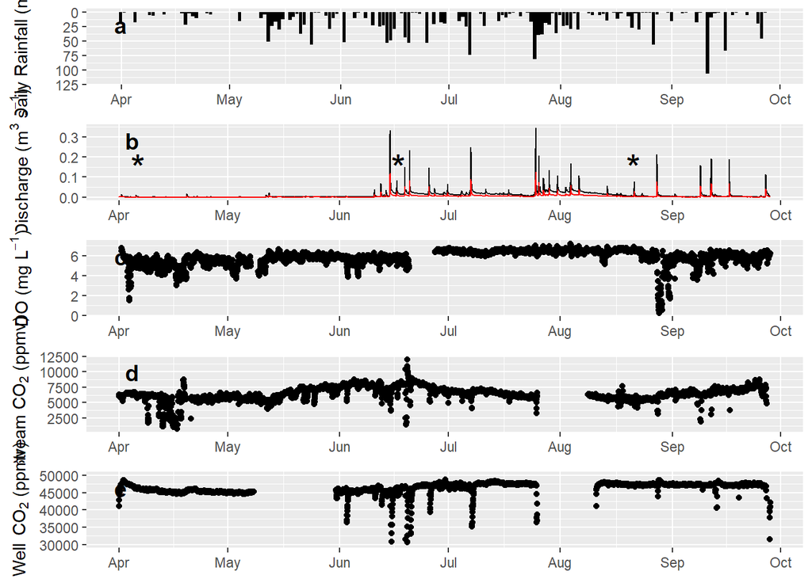

```r
# panel a) daily rainfall
rain_plot = ggplot(Tac_all %>%
                     group_by(Date = date(Timestamp)) %>%
                     summarise(dayRain = sum(Rainfall, na.rm = TRUE)),
                   aes(x = as.POSIXct(Date)))+
  geom_bar(aes(y = dayRain), stat = 'identity', fill = 'black')+
  ylim(120, 0)+
  ylab('Daily Rainfall (mm)')+
  scale_x_datetime(date_breaks = "1 month", date_labels =  "%b")+
  theme(axis.title.x = element_blank())

# panel b) mean hourly discharge
Q_plot = ggplot(Tac_all, aes(x = Timestamp))+
  geom_line(aes(y = meanQ_m3_s),
            color = 'black')+
  geom_line(aes(y = GW_Q/60),
            color = 'red')+
  ylab(expression(paste("Discharge (", m^3," ", s^-1,")")))+
  scale_color_manual(values = c('black',
                                'red'))+
  scale_x_datetime(date_breaks = "1 month",
                   date_labels =  "%b")+
  theme(axis.title.x = element_blank())+
  annotate('text',
           x = as.POSIXct(c('2013-04-6 00:00',
                 '2013-06-17 00:00',
                 '2013-08-21 00:00')),
           y = 0.15,
           label = "*",
           size = 8)

# panel c) dissolved oxygen
DO = ggplot(data = Tac_all, aes(x = Timestamp))+
  geom_point(aes(y = DO.obs))+
  labs(x = "Time", y = expression(paste("DO (mg " ,L^{-1},")")))+
  #ylim(0,8.5)+
  theme(axis.title.x = element_blank())+
  scale_x_datetime(date_breaks = "1 month", labels = date_format("%b"))

# panel d) stream pCO2
strCO2_plot = ggplot(Tac_all, aes(x = Timestamp))+
  geom_point(aes(y = CO2_ppm), color = 'black')+
  ylab(expression(paste("Stream ", CO[2]," ", "(ppmv)")))+
  scale_x_datetime(date_breaks = "1 month", date_labels =  "%b")+
  theme(axis.title.x = element_blank())

# panel e) well pCO2
wellCO2_plot = ggplot(Tac_all, aes(x = Timestamp))+
  geom_point(aes(y = wellCO2), color = 'black')+
  ylab(expression(paste("Well ", CO[2]," ", "(ppmv)")))+
  scale_x_datetime(date_breaks = "1 month", date_labels =  "%b")+
  theme(axis.title.x = element_blank())+
  ylim(30000, 50000)

# combine into Fig 2
plot_grid(rain_plot, Q_plot, DO, strCO2_plot, wellCO2_plot,
          nrow = 5,
          align = 'hv',
          labels = 'auto', hjust = -9, vjust = 2)
```

### Fig 3

```r
# subset the data and calculate the departure in umol L-1
Tac_departure = Tac_all %>%
  dplyr::select(Timestamp, Osat, DO.obs, CO2_aq, CO2_sat) %>%
  mutate(CO2_dep = (CO2_aq - CO2_sat)*1000,          # umol/L
         O2_dep = ((DO.obs - Osat)/32)*1000)         # umol/L

# calculate ellipsis for all data
Tac_dep_clean = na.omit(Tac_departure)
Tac_dep_clean$month = lubridate::month(Tac_dep_clean$Timestamp,
                                       abbr = TRUE, label = TRUE)

# calculate info for Table 2
Tac_mu = c(mean(Tac_dep_clean$CO2_dep, na.rm = TRUE),
           mean(Tac_dep_clean$O2_dep, na.rm = TRUE))
Tac_corMat = cor(cbind(Tac_dep_clean$CO2_dep,
                       Tac_dep_clean$O2_dep))
Tac_covMat = cov(cbind(Tac_dep_clean$CO2_dep,
                       Tac_dep_clean$O2_dep))
Tac_evals = eigen(Tac_covMat)$values
Tac_ell_length = 2*sqrt(5.991*Tac_evals)


Tac_reg = lmodel2(data = Tac_dep_clean,
                  O2_dep ~ CO2_dep, nperm = 99)
```

```
## RMA was not requested: it will not be computed.
```

```r
Tac_inter = Tac_reg$regression.results[2,2]
Tac_slope = Tac_reg$regression.results[2,3]
Tac_corr = Tac_reg$r

Tac_metrics = data.frame(meanCO2dep = Tac_mu[1],
                         meanO2dep = Tac_mu[2],
                         offset = Tac_mu[1] + Tac_mu[2],
                         EQ = 1/abs(Tac_slope),
                         width = Tac_ell_length[2],
                         stretch = Tac_ell_length[1])
Tac_metrics
```

```
##   meanCO2dep meanO2dep   offset       EQ    width  stretch
## 1   204.2567 -31.77724 172.4794 9.913518 120.6049 185.9119
```

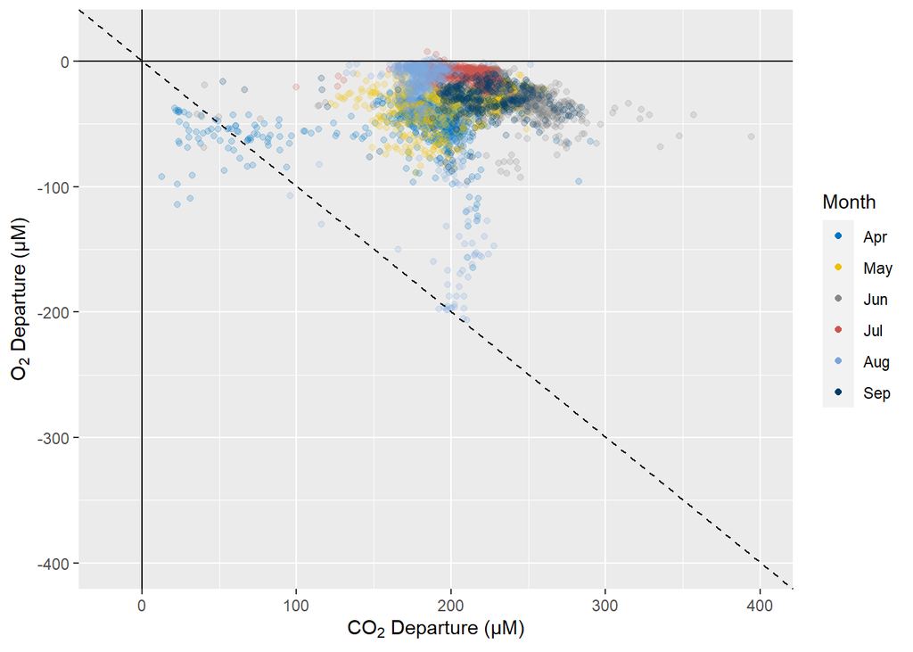

```r
# plot for all data points with 95% CI ellipsis
all_dep = ggplot()+
  geom_point(alpha = 0.2,
             data = Tac_departure,
             aes(x = CO2_dep, y = O2_dep,
                 color = factor(month(Timestamp))))+
  geom_hline(yintercept = 0)+
  geom_vline(xintercept = 0)+
  geom_abline(intercept = 0, slope = -1, linetype = 2)+
  xlim(-20, 400)+
  ylim(-400, 20)+
  xlab(expression(paste(CO[2], " Departure (µM)")))+
  ylab(expression(paste(O[2], " Departure (µM)")))+
  guides(colour = guide_legend(override.aes = list(alpha = 1)))+
  scale_color_jco(name = "Month",
                  labels = c("Apr", "May", "Jun", "Jul", "Aug", "Sep"))
all_dep
```

### Fig 4

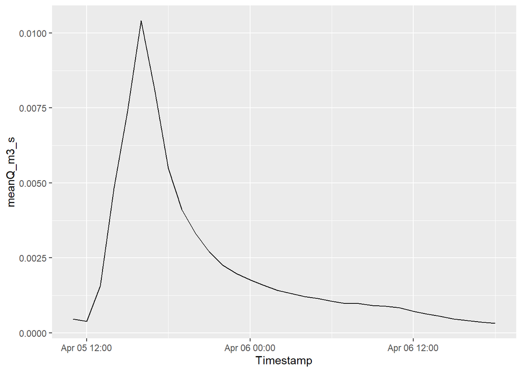

```r
# subset the dry season rainfall event
event_dry = Tac_all %>%
  dplyr::filter(Timestamp > "2013-04-05 06:00:00",
                Timestamp < "2013-04-06 15:00:00") %>%
  dplyr::select(Timestamp, meanQ_m3_s, Rainfall, CO2_ppm, DO.obs, wellCO2) %>%
  dplyr::mutate(obs = 1:dplyr::n())

# time series of the event
ggplot(event_dry, aes(Timestamp, meanQ_m3_s))+
  geom_line()
```

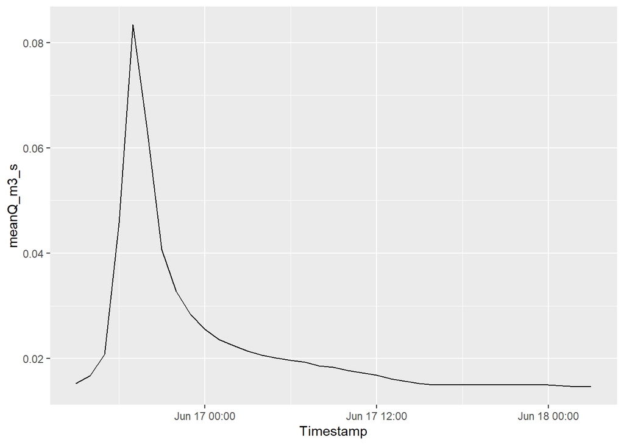

```r
hyst_dry = ggplot(event_dry,
                  aes(x = meanQ_m3_s, y = CO2_ppm,color = obs))+
  geom_point(size = 1)+
  geom_path(linejoin = "round", lineend = "square",
            arrow = arrow(angle = 30,
                          ends = 'last',
                          type = 'closed',
                          length = unit(0.1, 'inch')))+
  scale_color_viridis_c(name = "Hour")+
  ylab(expression(paste(pCO[2], " (ppmv)")))+
  xlab(expression(paste("Discharge (", m^3," ", s^{-1},")")))+
  scale_y_continuous(limits = c(3000, 9000),
                     breaks = c(3000, 6000, 9000),
                     labels = c(3000, 6000, 9000))


# early wet season event
## subset data
event_earlyWet = Tac_all %>%
  dplyr::filter(Timestamp > "2013-06-16 10:00:00",
                Timestamp < "2013-06-18 00:00:00") %>%
  dplyr::select(Timestamp, meanQ_m3_s, Rainfall, CO2_ppm, DO.obs, wellCO2) %>%
  dplyr::mutate(obs = 1:dplyr::n())

# plot the hydrograph
ggplot(event_earlyWet, aes(Timestamp, meanQ_m3_s))+
  geom_line()
```

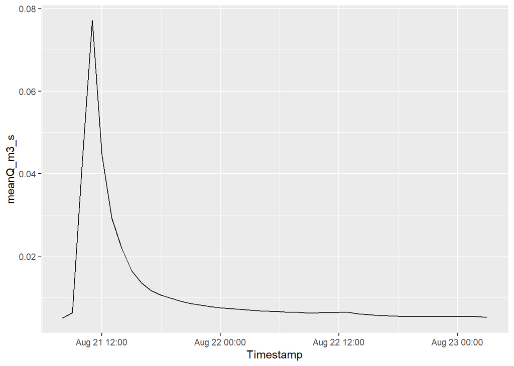

```r
# Hysteresis plot
hyst_earlyWet = ggplot(event_earlyWet, aes(x = meanQ_m3_s, y = CO2_ppm,
                      color = obs))+
  geom_point(size = 1)+
  geom_path(linejoin = "round", lineend = "square",
            arrow = arrow(angle = 30,
                          ends = 'last',
                          type = 'closed',
                          length = unit(0.1, 'inch')))+
  scale_color_viridis_c(name = "Hour")+
  ylab(expression(paste(pCO[2], " (ppmv)")))+
  xlab(expression(paste("Discharge (", m^3," ", s^{-1},")")))+
  scale_y_continuous(limits = c(3000, 9000),
                     breaks = c(3000, 6000, 9000),
                     labels = c(3000, 6000, 9000))

# late wet season event ----

event_lateWet = Tac_all %>%
  dplyr::filter(Timestamp > "2013-08-21 03:00:00",
                Timestamp < "2013-08-23 00:00:00") %>%
  dplyr::select(Timestamp, meanQ_m3_s, Rainfall, CO2_ppm, DO.obs, wellCO2) %>%
  dplyr::mutate(obs = 1:dplyr::n())

# hydrograph
ggplot(event_lateWet, aes(Timestamp, meanQ_m3_s))+
  geom_line()
```

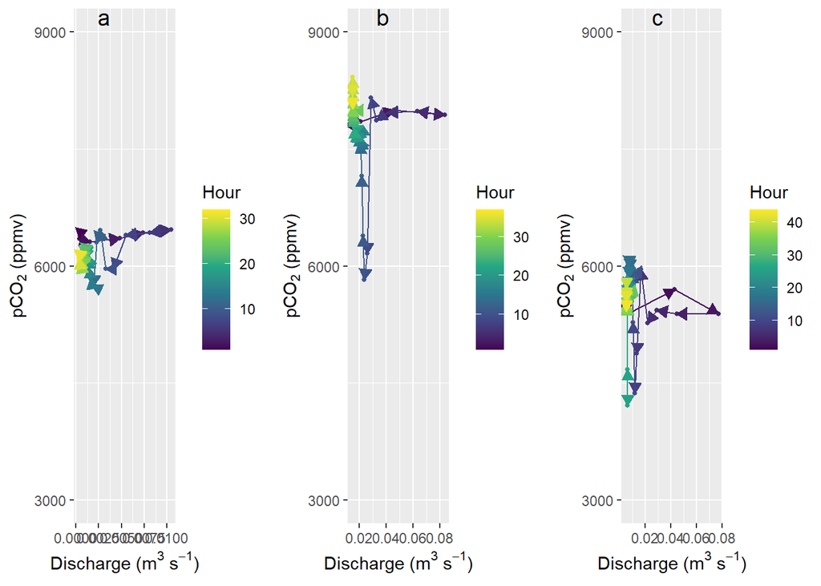

```r
# Hysteresis plot
hyst_lateWet = ggplot(event_lateWet, aes(x = meanQ_m3_s, y = CO2_ppm,
                           color = obs))+
  geom_point(size = 1)+
  geom_path(linejoin = "round", lineend = "square",
            arrow = arrow(angle = 30,
                          ends = 'last',
                          type = 'closed',
                          length = unit(0.1, 'inch')))+
  scale_color_viridis_c(name = "Hour",
                        labels = c(0, 10, 20, 30, 40, 50),
                        breaks = c(0, 10, 20, 30, 40, 50))+
  ylab(expression(paste(pCO[2], " (ppmv)")))+
  xlab(expression(paste("Discharge (", m^3," ", s^{-1},")")))+
  scale_y_continuous(limits = c(3000, 9000),
                     breaks = c(3000, 6000, 9000),
                     labels = c(3000, 6000, 9000))

Fig4 = plot_grid(hyst_dry, hyst_earlyWet, hyst_lateWet,
          ncol = 3, nrow = 1,
          labels = 'auto', label_fontface = 'plain',
          hjust = c(-8, -8, -9))
Fig4
```

### Fig 5

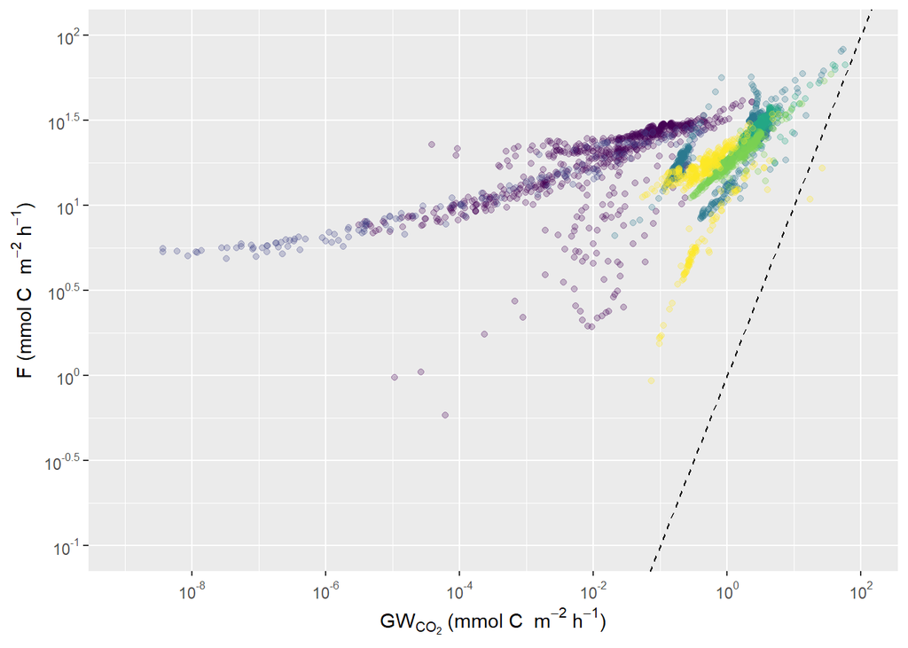

```r
F_from_GW = ggplot(Tac_scale,
                   aes(x = GWCO2*1000,
                       y = CO2_efflux*1000))+                     # convert to mmol
  geom_point(aes(color = factor(month(Timestamp,
                                      label = TRUE, abbr = TRUE))),
             alpha = 0.25)+
  geom_abline(aes(slope = 1, intercept = 0),
              linetype = 2)+
  scale_x_log10(limits = c(1e-9, 1e2),
                breaks = trans_breaks("log10", function(x) 10^x),
                labels = trans_format("log10", math_format(10^.x)))+
  scale_y_log10(limits = c(1e-1, 1e2),
                breaks = trans_breaks("log10", function(x) 10^x),
                labels = trans_format("log10", math_format(10^.x)))+
  scale_color_viridis_d(name = 'Month')+
  xlab(expression(paste(GW[CO[2]], ' (mmol C ', " ", m^-2," ", h^-1,")")))+
  ylab(expression(paste('F (mmol C ', " ", m^-2," ", h^-1,")")))+
  theme(legend.position = 'none')
F_from_GW
```

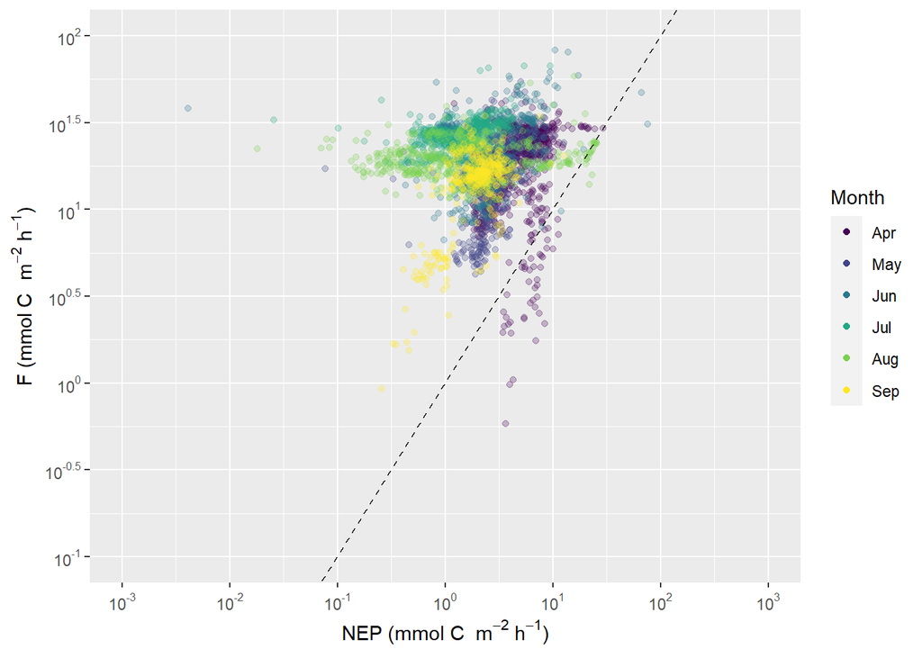

```r
F_from_NEP = ggplot(Tac_scale ,
                    aes(x = direct_met_mol*1000,
                        y = CO2_efflux*1000))+
  geom_point(aes(color = factor(month(Timestamp,
                                      label = TRUE, abbr = TRUE))),
             alpha = 0.25)+
  geom_abline(aes(slope = 1, intercept = 0),
              linetype = 2)+
  scale_x_log10(limits = c(1e-3, 1e3),
                breaks = trans_breaks("log10", function(x) 10^x),
                labels = trans_format("log10", math_format(10^.x)))+
  scale_y_log10(limits = c(1e-1, 1e2),
                breaks = trans_breaks("log10", function(x) 10^x),
                labels = trans_format("log10", math_format(10^.x)))+
  scale_color_viridis_d(name = 'Month')+
  xlab(expression(paste('NEP (mmol C ', " ", m^-2," ", h^-1,")")))+
  ylab(expression(paste('F (mmol C ', " ", m^-2," ", h^-1,")")))+
  guides(colour = guide_legend(override.aes = list(alpha = 1)))
F_from_NEP
```

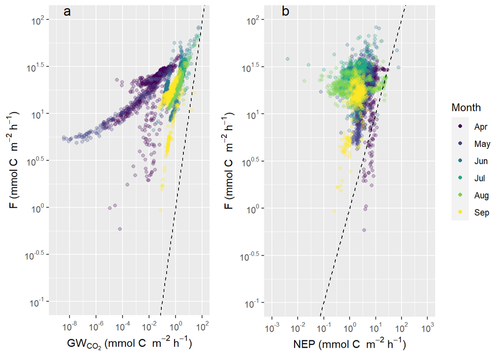

```r
Fig5 = plot_grid(F_from_GW, F_from_NEP,
                  ncol = 2,
                  rel_widths = c(0.75, 1),
                  labels = 'auto', label_fontface = 'plain',
                  hjust = -8.5, vjust = 1.5)
Fig5
```

### Fig 6

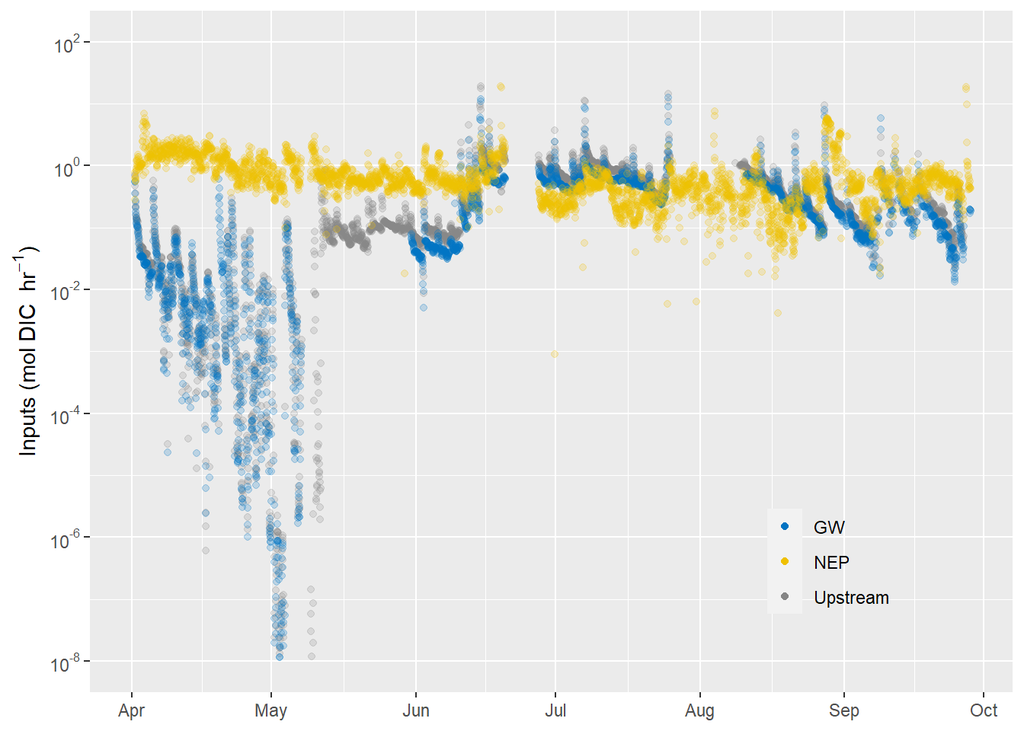

```r
Tac_scaled_in = ggplot(Tac_scale,
       aes(x = Timestamp))+
  geom_point(aes(y = DIC_in, color = 'Upstream'), alpha = 0.2)+
  geom_point(aes(y = GW_in, color = 'GW'), alpha = 0.2)+
  geom_point(aes(y = NEP_in, color = 'NEP'), alpha = 0.2)+
  scale_color_manual(values = c('#0073C2FF', '#EFC000FF', '#868686FF'))+
  ylab(expression(paste("Inputs (mol DIC "," ",hr^-1,")")))+
  scale_y_log10(limits = c(.00000001, 1e2),
                breaks = trans_breaks("log10", function(x) 10^x),
                labels = trans_format("log10", math_format(10^.x)))+
  scale_x_datetime(date_breaks = "1 month", date_labels =  "%b")+
  theme(legend.position = c(0.8, 0.2),
        legend.title = element_blank(),
        legend.background = element_blank(),
        axis.title.x = element_blank())+
  guides(colour = guide_legend(override.aes = list(alpha = 1)))
Tac_scaled_in
```

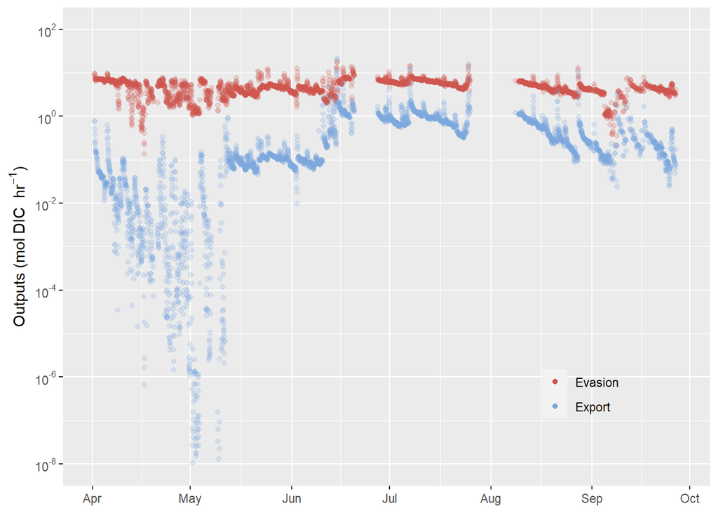

```r
Tac_scaled_out = ggplot(Tac_scale,
       aes(x = Timestamp))+
  geom_point(aes(y = F_out, color = 'Evasion'), alpha = 0.2)+
  geom_point(aes(y = DIC_out, color = 'Export'), alpha = 0.2)+
  scale_color_manual(values = c("#CD534CFF", "#7AA6DCFF"))+
  ylab(expression(paste("Outputs (mol DIC "," ",hr^-1,")")))+
  scale_y_log10(limits = c(.00000001, 1e2),
                breaks = trans_breaks("log10", function(x) 10^x),
                labels = trans_format("log10", math_format(10^.x)))+
  scale_x_datetime(date_breaks = "1 month", date_labels =  "%b")+
  theme(legend.position = c(0.8, 0.2),
        legend.title = element_blank(),
        legend.background = element_blank(),
        axis.title.x = element_blank())+
  guides(colour = guide_legend(override.aes = list(alpha = 1)))
Tac_scaled_out
```

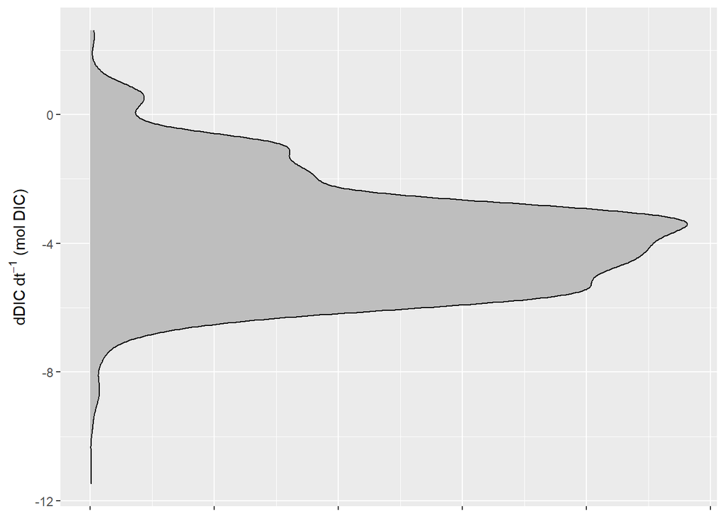

```r
Tac_scaled_dCdt = ggplot(Tac_scale)+
  geom_density(aes(x = dC_dt), fill = 'grey')+
  xlab(expression(paste("dDIC ", dt^-1, ' (mol DIC)')))+
  theme(axis.title.x = element_blank(),
        axis.text.x = element_blank())+
  coord_flip()
Tac_scaled_dCdt
```

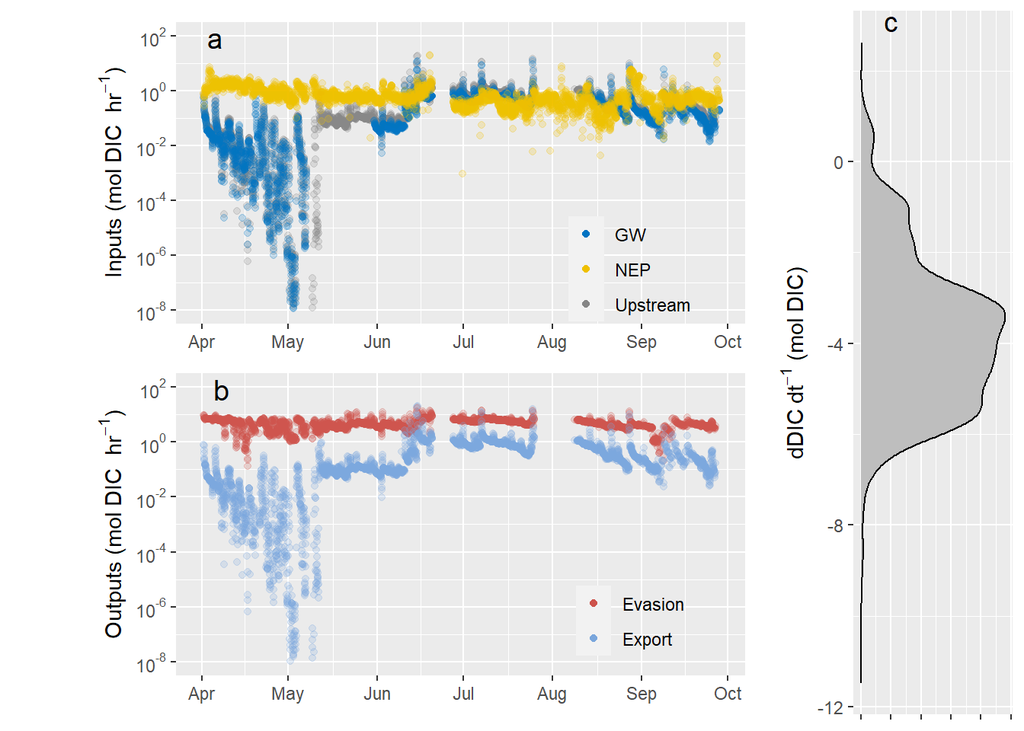

```r
Fig6 = plot_grid(plot_grid(Tac_scaled_in, Tac_scaled_out,
                    nrow = 2, align = 'hv',
                    labels = 'auto', label_fontface = 'plain',
                    hjust = -8, vjust = 1.75),
          Tac_scaled_dCdt,
          ncol = 2,
          rel_widths = c(3,1),
          labels = c('', 'c'), label_fontface = 'plain',
          hjust = -8,
          align = 'hv')
Fig6
```

### Fig 7

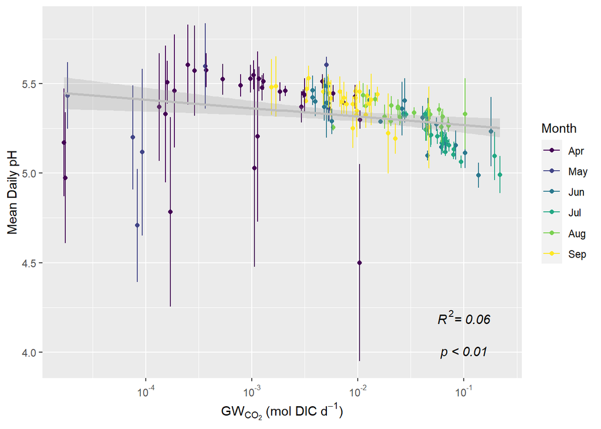

```r
Tac_corr = Tac_scale %>%
  group_by(Timestamp = date(Timestamp)) %>%
  summarise(sumGW = sum(GWCO2, na.rm = TRUE),
            sumF = sum(CO2_efflux, na.rm = TRUE),
            sumNEP = sum(direct_met_mol, na.rm = TRUE),
            sumDICin = sum(DIC_in, na.rm = TRUE),
            sumDICout = sum(DIC_out, na.rm = TRUE),
            sumrain = sum(Rainfall, na.rm = TRUE),
            meanpH = mean(pH, na.rm = TRUE),
            sdpH = sd(pH, na.rm = TRUE))

GW_cor_pH = ggplot(Tac_corr %>%
         filter(sumGW > 1e-5),
       aes(x = sumGW,
           y = meanpH))+
  geom_point(aes(color = month(Timestamp,
                               label = TRUE, abbr = TRUE)))+
  geom_errorbar(aes(ymin = meanpH - sdpH,
                    ymax = meanpH + sdpH,
                    color = month(Timestamp,
                                  label = TRUE, abbr = TRUE)))+
  geom_smooth(method = 'lm',
              color = 'grey',
              alpha = 0.25)+
  scale_x_log10(breaks = trans_breaks("log10", function(x) 10^x),
                labels = trans_format("log10", math_format(10^.x)))+
  scale_color_viridis_d(name = 'Month')+
  xlab(expression(paste(GW[CO[2]], ' (mol DIC ', d^-1, ")")))+
  ylab('Mean Daily pH')+
  annotate(x = 0.1, y = 4, 'text', label = expression(italic("p < 0.01")))+
  annotate(x = 0.1, y = 4.2, 'text', label = expression(italic(paste(R^2,"= 0.06"))))
GW_cor_pH
```

## Supplemental Figure

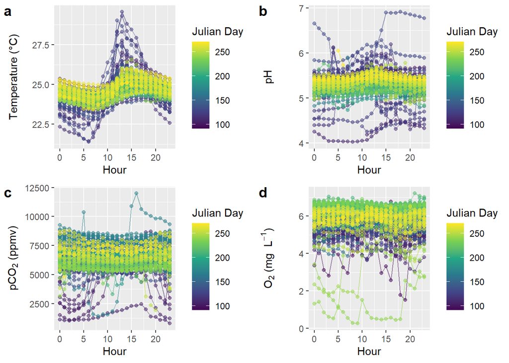

```r
# temperature
tempHour = ggplot(Tac_all, aes(x = hour(Timestamp), y = temp.water))+
  geom_line(alpha = 0.5, aes(group = yday(Timestamp), color = yday(Timestamp)))+
  geom_point(alpha = 0.5, aes(group = yday(Timestamp), color = yday(Timestamp)))+
  xlab('Hour')+
  scale_colour_viridis_c(name = "Julian Day")+
  theme(legend.title = element_text(face = 'plain'))+
  ylab("Temperature (°C)")

# pH
pHHour = ggplot(Tac_all, aes(x = hour(Timestamp), y = pH))+
  geom_line(alpha = 0.5, aes(group = yday(Timestamp), color = yday(Timestamp)))+
  geom_point(alpha = 0.5, aes(group = yday(Timestamp), color = yday(Timestamp)))+
  labs(x = 'Hour', y = "pH")+
  scale_colour_viridis_c(name = "Julian Day")+
  theme(legend.title = element_text(face = 'plain'))

# stream CO2, ppm
CO2Hour = ggplot(Tac_all, aes(x = hour(Timestamp), y = CO2_ppm))+
  geom_line(alpha = 0.5, aes(group = yday(Timestamp), color = yday(Timestamp)))+
  geom_point(alpha = 0.5, aes(group = yday(Timestamp), color = yday(Timestamp)))+
  xlab('Hour')+
  ylab(expression(paste(pCO[2], ' (ppmv)')))+
  scale_colour_viridis_c(name = "Julian Day")+
  theme(legend.title = element_text(face = 'plain'))

# dissolved oxygen
DOHour = ggplot(Tac_all, aes(x = hour(Timestamp), y = DO.obs))+
  geom_line(alpha = 0.5, aes(group = yday(Timestamp), color = yday(Timestamp)))+
  geom_point(alpha = 0.5, aes(group = yday(Timestamp), color = yday(Timestamp)))+
  xlab('Hour')+
  ylab(expression(paste(O[2], " (mg "," ",L^{-1},")")))+
  scale_colour_viridis_c(name = 'Julian Day')+
  theme(legend.title = element_text(face = 'plain'))

FigS1 = plot_grid(tempHour, pHHour, CO2Hour, DOHour,
                  ncol = 2, nrow = 2, align = 'hv',
                  labels = 'auto')
FigS1
```

**R version 4.0.3 (2020-10-10)**

**Platform:** x86_64-w64-mingw32/x64 (64-bit)

**locale:** *LC_COLLATE=English_United States.1252*, *LC_CTYPE=English_United States.1252*, *LC_MONETARY=English_United States.1252*, *LC_NUMERIC=C* and *LC_TIME=English_United States.1252*

**attached base packages:** *stats*, *graphics*, *grDevices*, *utils*, *datasets*, *methods* and *base*

**other attached packages:** *purrr(v.0.3.4)*, *ggsci(v.2.9)*, *ellipse(v.0.4.2)*, *lmodel2(v.1.7-3)*, *scales(v.1.1.1)*, *tidyquant(v.1.0.3)*, *quantmod(v.0.4.18)*, *TTR(v.0.24.2)*, *PerformanceAnalytics(v.2.0.4)*, *xts(v.0.12.1)*, *zoo(v.1.8-9)*, *pander(v.0.6.3)*, *ggrepel(v.0.9.1)*, *cowplot(v.1.1.1)*, *ggplot2(v.3.3.3)*, *lubridate(v.1.7.10)*, *tidyr(v.1.1.3)* and *dplyr(v.1.0.6)*

**loaded via a namespace (and not attached):** *tidyselect(v.1.1.0)*, *xfun(v.0.23)*, *bslib(v.0.2.4)*, *splines(v.4.0.3)*, *lattice(v.0.20-41)*, *colorspace(v.2.0-0)*, *vctrs(v.0.3.8)*, *generics(v.0.1.0)*, *viridisLite(v.0.4.0)*, *htmltools(v.0.5.1.1)*, *mgcv(v.1.8-35)*, *yaml(v.2.2.1)*, *utf8(v.1.1.4)*, *rlang(v.0.4.10)*, *jquerylib(v.0.1.3)*, *pillar(v.1.6.0)*, *glue(v.1.4.2)*, *withr(v.2.4.2)*, *DBI(v.1.1.1)*, *lifecycle(v.1.0.0)*, *stringr(v.1.4.0)*, *Quandl(v.2.10.0)*, *munsell(v.0.5.0)*, *gtable(v.0.3.0)*, *evaluate(v.0.14)*, *labeling(v.0.4.2)*, *knitr(v.1.32)*, *curl(v.4.3)*, *fansi(v.0.4.1)*, *highr(v.0.9)*, *Rcpp(v.1.0.5)*, *jsonlite(v.1.7.2)*, *farver(v.2.1.0)*, *digest(v.0.6.27)*, *stringi(v.1.5.3)*, *grid(v.4.0.3)*, *quadprog(v.1.5-8)*, *cli(v.2.4.0)*, *tools(v.4.0.3)*, *magrittr(v.2.0.1)*, *sass(v.0.3.1)*, *tibble(v.3.0.4)*, *crayon(v.1.4.1)*, *pkgconfig(v.2.0.3)*, *Matrix(v.1.3-2)*, *ellipsis(v.0.3.1)*, *assertthat(v.0.2.1)*, *rmarkdown(v.2.7)*, *httr(v.1.4.2)*, *rstudioapi(v.0.13)*, *R6(v.2.5.0)*, *nlme(v.3.1-152)* and *compiler(v.4.0.3)*